# Strategic Journal Targeting

Evidence-Based Journal Selection from Recent Publications

Yusri Yusup

Wan Zafira Wan Zakaria

Lee Chee Keong

Norli Ismail

Abdorezza Mohammad Nafchi

Mohd Nurazzi Norizan

Melbi Mahardika

30 January 2026

**Prepared by:**  
Research Trends Committee,  
School of Industrial Technology, Universiti Sains Malaysia

## Executive Summary

This report presents an evidence-based overview of journals in which PPTI academics have successfully published in the last two years. It is intended to support:

- **Strategic journal targeting** for new manuscript submissions
- **Reduction of desk rejections** through scope and outlet alignment
- **Informed publication planning** aligned with PPTI research strengths

Key insights from the analysis show that: - A focused set of journals consistently accepts PPTI work - Several outlets demonstrate both **high publication frequency** and **strong citation visibility** - Open-access and hybrid journals feature prominently, supporting funder mandates

This document should be used as a **living reference**, updated periodically to reflect emerging publication trends and shifts in journal performance.

## Report Objective

This report lists journals where PPTI lecturers published within the **last two years**.  
It serves as a **recommended journal targeting reference** for future manuscript submissions.

**How to use this report**

- Use the search box to find journals quickly.
- Sort by **Total Citations** to identify high-impact outlets.
- Click Scopus links to view the top cited articles.

## Summary

### Total Target Journals: **373**

### Total PPTI Contributors: **69**

Total Target Journals

373

📚

Total PPTI Contributors

69

👩‍🔬

Publication Window

2023–2025

🗓️

## Recommended Journal Target List

| Journal | Publication_Count | Total_Citations | Open Access |
| --- | --- | --- | --- |
| International Journal of Biological Macromolecules | 60 | 787 | Open |
| Polymer Engineering and Science | 25 | 90 | NA |
| Journal of Food Measurement and Characterization | 21 | 43 | Open |
| Aip Conference Proceedings | 21 | 9 | Open |
| Express Polymer Letters | 19 | 53 | Open |
| Polymer Composites | 14 | 116 | NA |
| Biofuels Bioproducts and Biorefining | 13 | 21 | Open |
| Bioremediation Technologies for Wastewater and Sustainable Circular Bioeconomy | 13 | 15 | NA |
| Solid Waste Management Challenges and Recent Solutions | 12 | 2 | NA |
| Biomass Conversion and Biorefinery | 11 | 117 | NA |

[output cut: 363 more lines]

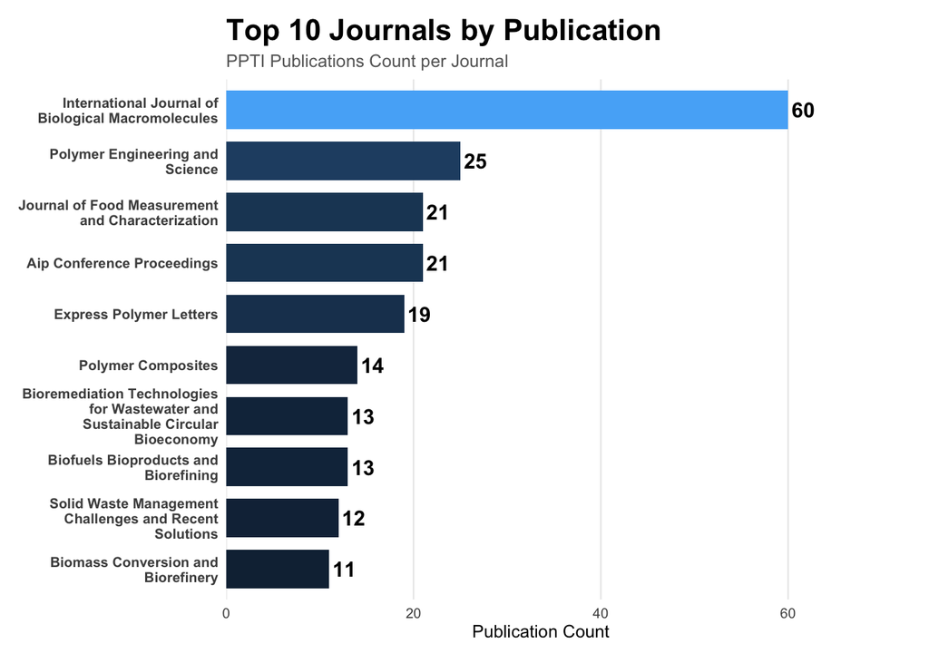

# Interpretation Guide

- **Citations**: Visibility and research influence
- **Open Access**: Suitable for grant-funded and high-impact dissemination
- **Publication Count**: Proven PPTI publication success
- **Scopus Link**: Reference article for targeting and scope matching

# Auto Generated Time

Report generated on:

**2026-01-30 17:03:37.751679**